# Lab 01 - Hello R

Ben Hardin

1/13/2023

## Load packages and data

```r
library(tidyverse)
library(datasauRus)
```

## Exercises

### Exercise 1

The datasaurus_dozen dataframe has 1846 rows and 3 columns, or variables. These variables are:

1. dataset - which dataset the data are from
2. x - x-values
3. y - y-values

### Exercise 2

The purpose of this exercise is to visualize and describe the relationship between variables x & y in the dino dataset.

The first part of code below filters out all the datasets in the datasaurus_dozen data frame besides the dino dataset, so that we can plot that dataset specifically.

The second part of the code creates a scatterplot of values x & y using the ggplot function. The arguments (1) select the filtered dataset we just made, (2) assigns the x variable to the x axis and the y variable to the y axis, (3) chooses points as our shape for representing each datapoint. The result is a beautiful dinosaur!

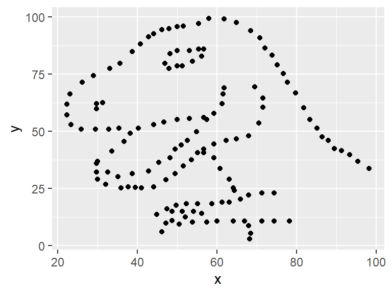

```r
dino_data <- datasaurus_dozen %>%
  filter(dataset == "dino")

ggplot(data = dino_data, mapping = aes(x = x, y = y)) +
  geom_point()
```

Finally, the code below calculates the correlation between x and y in the dino dataset and makes a table showing the correlation coefficient (r = -.065). This correlation sadly is misleading and does not capture the majesty of the dinosaur.

```r
dino_data %>%
  summarize(r = cor(x, y))
```

```
## # A tibble: 1 × 1
##         r
##     <dbl>
## 1 -0.0645
```

### Exercise 3

The purpose of this exercise is to visualize and describe the star dataset.

The code chunk below replicates the code we used above for the dino dataset, except this time we are filtering for the star dataset instead. As we might expect from the name, the scatterplot of x & y for this dataset looks like a star.

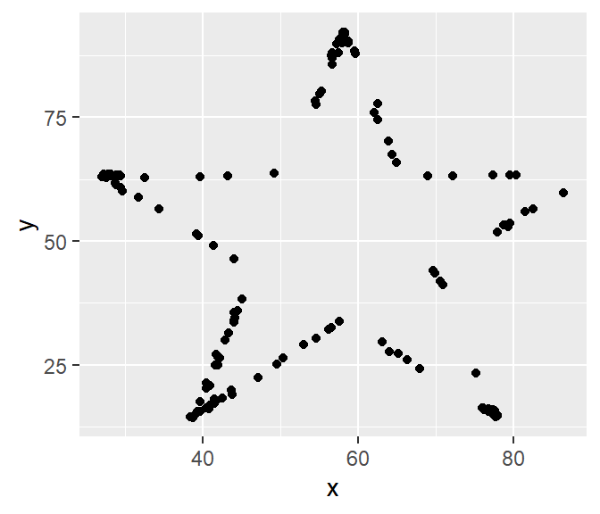

```r
star_data <- datasaurus_dozen %>%
  filter(dataset == "star")

ggplot(data = star_data, mapping = aes(x = x, y = y)) +
  geom_point()
```

Now, we can see how x & y are correlated in this dataset. Again, all we have to do is re-use our code from above, but now using the star dataset we made earlier.

The correlation between x & y is almost exactly the same as in the dino dataset, but very slightly smaller (r = -.063).

```r
star_data %>%
  summarize(r = cor(x, y))
```

```
## # A tibble: 1 × 1
##         r
##     <dbl>
## 1 -0.0630
```

### Exercise 4

The purpose of this exercise is to visualize and describe the circle dataset.

Just like before, we can re-use the same code except filtering for the circle dataset this time. When we plot x & y, we get a circle shaped scatterplot!

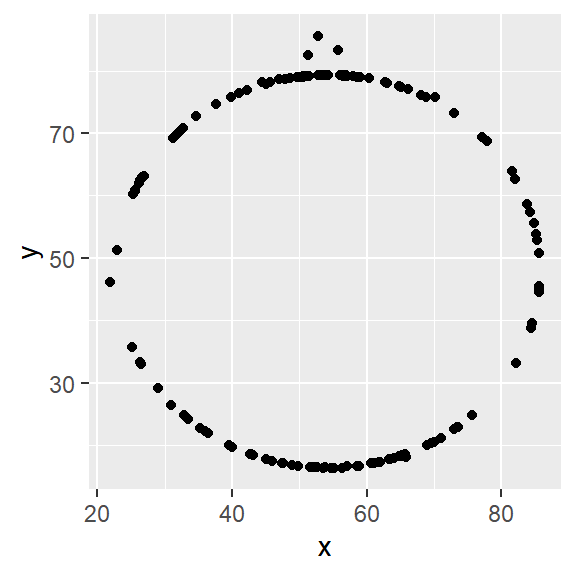

```r
circle_data <- datasaurus_dozen %>%
  filter(dataset == "circle")

ggplot(data = circle_data, mapping = aes(x = x, y = y)) +
  geom_point()
```

The correlation between x & y in the circle dataset is extremely close to what we saw in the dino and star datasets, but very slightly larger (r = -.068)

```r
circle_data %>%
  summarize(r = cor(x, y))
```

```
## # A tibble: 1 × 1
##         r
##     <dbl>
## 1 -0.0683
```

### Exercise 5

The purpose of exercise 5 is to visualize and describe all the datasets in the datasaurus dozen.

The code chunk below allows us to generate scatterplots for each of the different datasets all at once, by “faceting” the full dataframe by the dataset variable. The result is a grid where each cell is a scatterplot of one of the facets, or datasets. Now we can see the shape of the relationship between x & y in each of these different datasets in one figure.

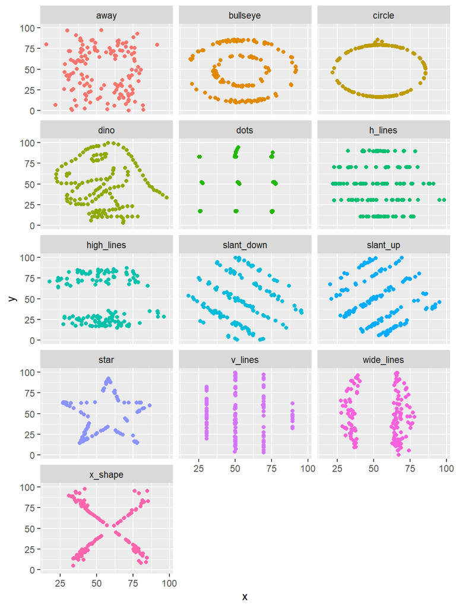

```r
ggplot(datasaurus_dozen, aes(x = x, y = y, color=dataset))+
  geom_point()+
  facet_wrap(~ dataset, ncol = 3)+
  theme(legend.position = "none")
```

Finally, we can calculate the correlation between x & y separately for each dataset all at once, by grouping our data by the dataset variable. Results show that, although the shape of relationship between x & y is very different between these datasets, they all show virtually the same correlation (rs = -.06 to -.069).

```r
datasaurus_dozen %>%
  group_by(dataset) %>%
  summarize(r = cor(x, y))
```

```
## # A tibble: 13 × 2
##    dataset          r
##    <chr>        <dbl>
##  1 away       -0.0641
##  2 bullseye   -0.0686
##  3 circle     -0.0683
##  4 dino       -0.0645
##  5 dots       -0.0603
##  6 h_lines    -0.0617
##  7 high_lines -0.0685
##  8 slant_down -0.0690
##  9 slant_up   -0.0686
## 10 star       -0.0630
## 11 v_lines    -0.0694
## 12 wide_lines -0.0666
## 13 x_shape    -0.0656
```

## Bonus Tips by Yoo Ri

Here are some helpful tips :)

- filter() is for extracting rows
- group_by() is for grouping datasets by assigned column
- ungroup() cancels the grouping
- summarize() is often used with group_by(). This function can print the output according to the group_by().
- facet_grid(y~x,…) creates a grid with variable y as a row, variable x as a column
- facet_wrap(x,… ) is useful when there is only one variable